# Sårbarhetsanalys

## Malung-Sälen

Malung-Sälen är Dalarnas fjärde minsta kommun sett till folkmängd och hade 10 207 invånare i november 2025, vilket är något färre än vid utgången av 2024. Efter att ha minskat under en lång period, började folkmängden att öka i mitten på 2010-talet. Värt att notera är dessutom att Malung-Sälens kommun har ett relativt stort antal säsongsarbetande (Sälenfjällen) och många fritidshus, varför befolkningen är klart större vintertid. Malung-Sälen har Dalarnas lägsta arbetslöshet, 2,4 procent, samtidigt som andelen högutbildade i länet är bland de lägsta. Vidare är kopplingen mellan andelen utrikes födda och nivån av arbetslöshet inte lika tydlig i Malung-Sälens kommun som i många andra kommuner. Noterbart är även att kommunen har den lägsta andelen in- och utpendling bland Dalarnas kommuner, vilket delvis kan tillskrivas kommunens läge och geografiska storlek.

I Malung-Sälen står turismindustrin i Sälenfjällen för en stor andel av sysselsättningen, men trots detta arbetar den största andelen av de förvärvsarbetande inom vård och omsorg. Detta kan delvis förklaras av att turism är en svår bransch att definiera. Exempelvis ryms sannolikt en stor del av Sälenfjällens anställda inom branschgruppen “kultur, fritid och nöje” i figuren, som tillsammans med hotell- och restaurangbranschen räknas till turismindustrin.

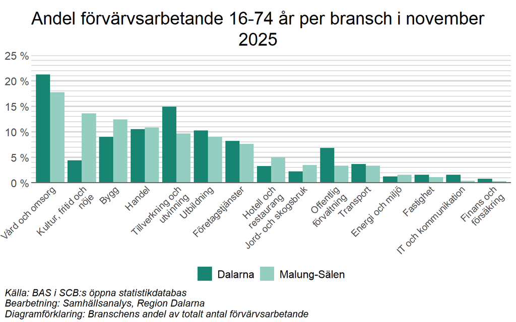

Baserat på andelen av lönesumman inom det privata näringslivet är renhållning, kultur, sport m.m. den största branschgruppen, med drygt 17 procent av den totala lönesumman. Att renhållning ingår i namnet på branschgruppen behöver man inte fästa någon större vikt vid, det handlar primärt om arbetsgivare inom turism. Branschgruppen utgörs av en jämställd representation av kvinnor och män, men har relativt få utrikes födda och få högutbildade. I övrigt är företag inom byggindustri viktiga i Malung-Sälen, branschgruppen står för 15 procent av den totala lönesumman, vilket illustrerar effekterna av den “byggboom” som skett i Dalarnas fjällvärld på senare år som en expanderande turismindustrin bidragit till. Representationen bland de sysselsatta i byggindustrin i Malung-Sälen följer mönstret för Sverige med relativt få kvinnor, få utrikes födda, såväl som få med högre utbildning. Viktigt att notera när det gäller Malung-Sälens kommun är att anställda inom många olika branschgrupper kan vara kopplade till Sälenfjällens ekonomi. Om de som städar hotell och stugor inte arbetar för företaget som driver anläggningen, återfinns de sannolikt inom branschgruppen företagsservicefirmor. I Malung-Sälen är 35 procent av de anställda inom den branschgruppen utrikes födda, vilket är en väldigt stor andel.

De fem största branscherna i Malung-Sälen 2023 inom det privata näringslivet

| Bransch | Sysselsatta | Lönesumma (%)<sup>1</sup> | Kvinnor (%)<sup>2</sup> | Högutbildade (%)<sup>2,3</sup> | Utrikes födda (%)<sup>2</sup> |
| --- | --- | --- | --- | --- | --- |
| Renhållning kultur sport m.m. | 1135 | 17 | 52 | 17 | 15 |
| Byggindustri | 700 | 15 | 13 | 10 | 5 |
| Parti- o detaljhandel rep av hushållsartiklar | 956 | 14 | 53 | 13 | 8 |
| Hotell o restaurang | 1055 | 11 | 52 | 12 | 22 |
| Företagsservicefirmor | 682 | 9 | 45 | 25 | 35 |

Källa: SCB, bearbetning: Samhällsanalys, Region Dalarna, * -> för litet tal  
<sup>1</sup> Andel av total lönesumma inom det privata näringslivet  
<sup>2</sup> Andel inom bransch  
<sup>3</sup> Med högutbildade menas eftergymnasialt utbildade i denna tabell.

Den största arbetsgivaren i Malung-Sälen var år 2023 Malung-Sälens Kommun med runt 1 000 anställda. Skistar är den största privata arbetsgivaren med strax över 600 anställda.

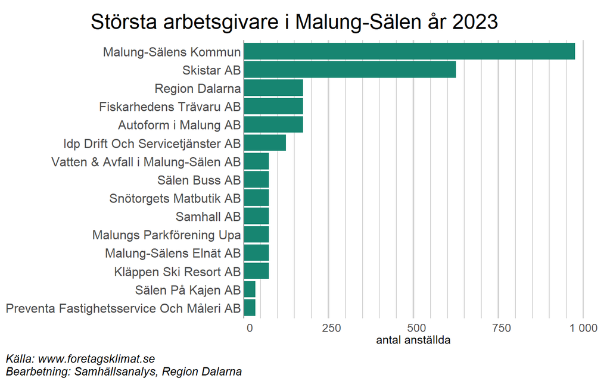

Malung-Sälen är den kommun i Dalarna som har klart störst antal privata arbetsställen per 1000 invånare, vilket är en indikator på ett bra företagsklimat. Det startas dessutom många företag i Malung-Sälen.

I relation till sin befolkningsstorlek krävs relativt många företag i det privata näringslivet för att den aggregerade lönesumman skall uppgå till 50 procent av den totala lönesumman i kommunen, vilket är en indikator på att Malung-Sälen har ett relativt litet beroende av enskilda företag. Samtidigt är branschbredden i Malung-Sälen i linje med genomsnittet i Dalarna.

Sammanfattningsvis är Malung-Sälen en kommun som uppvisar låg sårbarhet på flera områden. Arbetslösheten är låg och det både startas, och finns, många företag. Dessutom är beroendet av enskilda branscher och arbetsgivare relativt litet som det verkar. På minussidan finns en låg pendling (Dalarnas lägsta) och ett relativt stort beroende av säsongsarbetande. Dessutom finns viss osäkerhet kopplad till främst klimatförändringar och dess påverkan på snötillgång och annat, men även till konjunkturen då exempelvis skidturism är en relativt dyr fritidsaktivitet. Viktigt att poängtera är också att den modell för att utvärdera sårbarhet som används i denna analys inte tar hänsyn till kopplingar mellan branscher, exempelvis hur många olika branscher som är kopplade till ekonomin runt turismen i Malung-Sälen.

## Mora

Mora kommun är Dalarnas femte största sett till folkmängd och hade 20 444 invånare i november 2025. Efter några år med minskande befolkning, ökade folkmängden tydligt från mitten av 2010-talet till 2022, innan den återigen började minska. Moras arbetslöshet, 2,4 procent, är klart under genomsnittet i Dalarna och dessutom har kommunen den tredje största andelen högutbildade. Den låga arbetslösheten kan delvis förklaras med att Mora har en relativt sett lägre andel utrikes födda i befolkningen, än i många andra Dalakommuner. Arbetslösheten har visat sig vara genomgående högre bland utrikes födda än bland inrikes födda. Vidare är Mora en kommun som många pendlar till, ungefär var fjärde förvärvsarbetande bor inte i kommunen.

Mora har ursprung från medeltiden och är idag kanske mest känt för Vasaloppet och Anders Zorn. Mer än var fjärde förvärvsarbetande arbetar inom vård och omsorg, vilket är en klart högre andel än genomsnittet i Dalarna. Detta beror till stor del på att ett av Dalarnas centralsjukhus, Mora lasarett, ligger i kommunen. I övrigt är andelen förvärvsarbetande per bransch ungefär i linje med snittet för Dalarna.

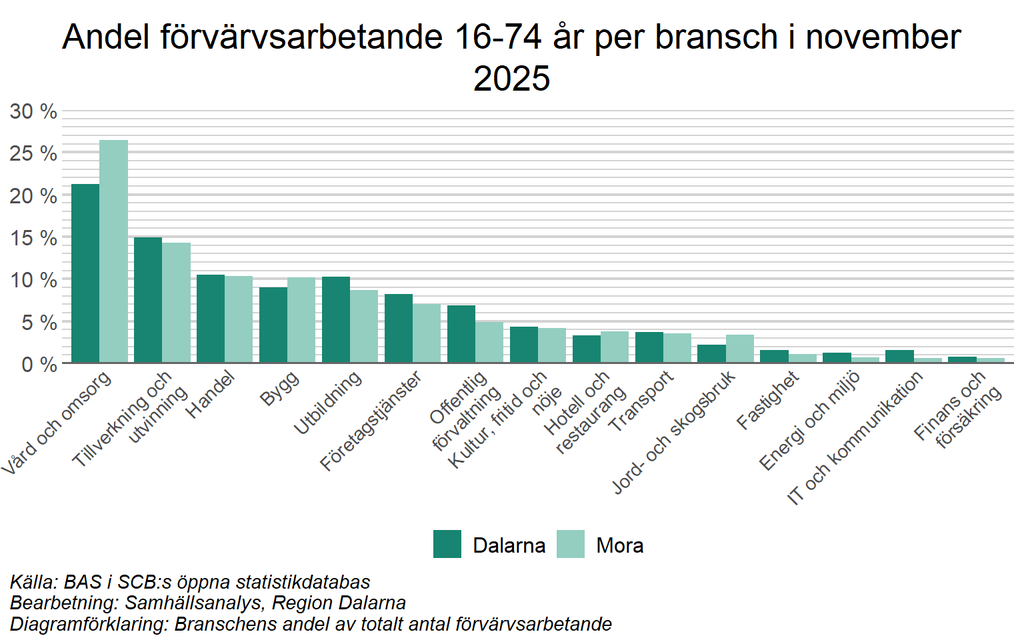

Bland arbetsgivare inom det privata näringslivet är branschgruppen byggindustri den största, såväl vad gäller sysselsatta som andel av den totala lönesumman (16 procent). Även företag inom metallvaruindustri, parti- och detaljhandel samt företagsservicefirmor är viktiga arbetsgivare, med runt 35 procent av den totala lönesumman tillsammans. Av dessa branschgrupper har parti och detaljhandel en jämnställd könsfördelning, medan många inom företagsservicefirmor (36 procent) har eftergymnasial utbildning.

De fem största branscherna i Mora 2023 inom det privata näringslivet

| Bransch | Sysselsatta | Lönesumma (%)<sup>1</sup> | Kvinnor (%)<sup>2</sup> | Högutbildade (%)<sup>2,3</sup> | Utrikes födda (%)<sup>2</sup> |
| --- | --- | --- | --- | --- | --- |
| Byggindustri | 1169 | 16 | 13 | 15 | 10 |
| Företagsservicefirmor | 1059 | 13 | 40 | 36 | 11 |
| Metallvaruindustri; ej maskinindustri | 796 | 12 | 20 | 22 | 13 |
| Parti- o detaljhandel rep av hushållsartiklar | 1075 | 11 | 56 | 19 | 7 |
| Hälso- o sjukvård omsorg | 969 | 7 | 76 | 31 | 20 |

Källa: SCB, bearbetning: Samhällsanalys, Region Dalarna, * -> för litet tal  
<sup>1</sup> Andel av total lönesumma inom det privata näringslivet  
<sup>2</sup> Andel inom bransch  
<sup>3</sup> Med högutbildade menas eftergymnasialt utbildade i denna tabell.

Den största arbetsgivaren i Mora var 2023 Mora Kommun med ungefär 2 000 anställda. Många i Mora jobbar även för Region Dalarna, medan Vi Omsorg och FM Mattson är de största privata arbetsgivarna med ungefär 300 anställda vardera.

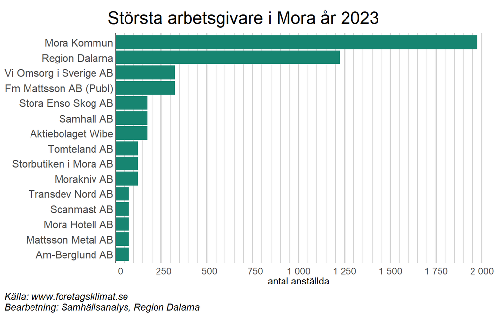

Precis som många andra kommuner i norra Dalarna har Mora ett stort antal arbetsställen i förhållande till sin befolkning, vilket är en indikation på ett väl fungerande företagande i kommunen. Samtidigt är dock antalet konkurser (per 1000 invånare) något högre än genomsnittet i Dalarna och har ökat på senare år.

Mora har en relativt stor branschbredd och rankar högt på antal företag som krävs för att lönesumman skall överstiga 50 procent inom det privata näringslivet, vilket indikerar att beroendet i kommunen är lågt. Samtidigt är, som nämnts tidigare, vård och omsorg en viktig arbetsgivare och på exempelvis Mora lasarett jobbar runt 1 000 personer.

Sammanfattningsvis uppvisar Mora låg sårbarhet på de flesta områden i den modell vi använder. Arbetslösheten är låg och utbildningsnivån hög, samtidigt som beroendet av enskilda branscher och företag inom det privata näringslivet är lågt. Den riskfaktor som kan skönjas, precis som var fallet med Falun, är det relativt stora beroendet av företag inom vård och omsorg, i mångt och mycket kopplat till Mora lasarett.

## Orsa

Orsa kommun, med 6 899 invånare, var Dalarnas tredje minsta kommun i november 2025. Folkmängden minskade från mitten av 1990-talet (åren efter finanskrisen) fram till mitten av 2010-talet, innan den ökade tydligt. Efter att ha minskat något på senare år, har befolkningen ökat hittils under 2025. Arbetslösheten i Orsa, 3,5 procent, är klart under genomsnittet i Dalarna, men andelen högutbildade är samtidigt klart lägre än genomsnittet. Pendlingen från Orsa till andra kommuner är hög och nästan varannan som bor i Orsa och förvärvsarbetar gör så i en annan kommun, vilket är positivt för arbetsmarknadens resiliens mot kriser. Medelåldern i Orsa, ungefär 47 år, är förhållandevis hög.

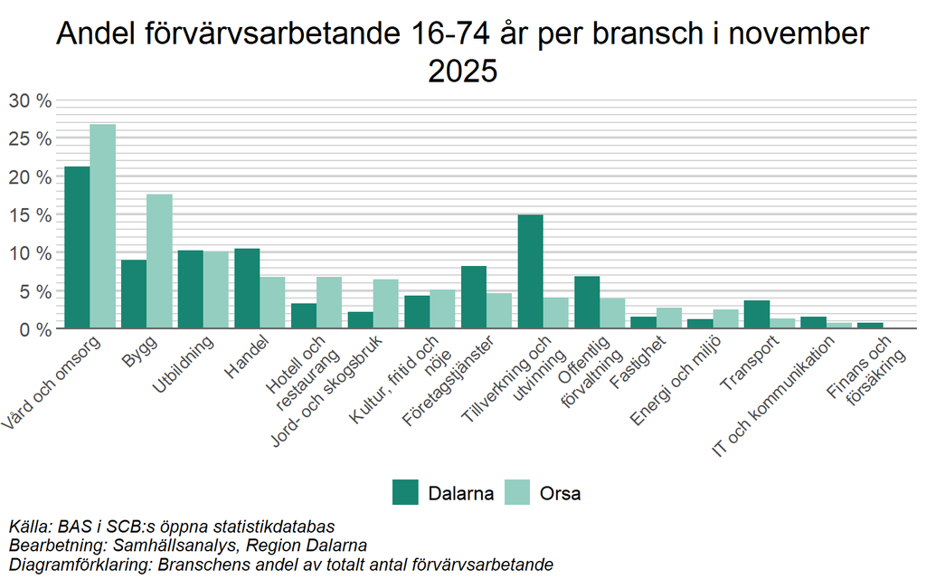

De fem största branscherna i Orsa 2023 inom det privata näringslivet

| Bransch | Sysselsatta | Lönesumma (%)<sup>1</sup> | Kvinnor (%)<sup>2</sup> | Högutbildade (%)<sup>2,3</sup> | Utrikes födda (%)<sup>2</sup> |
| --- | --- | --- | --- | --- | --- |
| Byggindustri | 424 | 28 | 11 | 6 | 4 |
| Hotell o restaurang | 327 | 12 | 55 | 17 | 27 |
| Parti- o detaljhandel rep av hushållsartiklar | 191 | 8 | 61 | 15 | 8 |
| Företagsservicefirmor | 166 | 8 | 30 | 26 | 10 |
| Skogsbruk | 132 | 8 | 12 | 23 | 4 |

Källa: SCB, bearbetning: Samhällsanalys, Region Dalarna, * -> för litet tal  
<sup>1</sup> Andel av total lönesumma inom det privata näringslivet  
<sup>2</sup> Andel inom bransch  
<sup>3</sup> Med högutbildade menas eftergymnasialt utbildade i denna tabell.

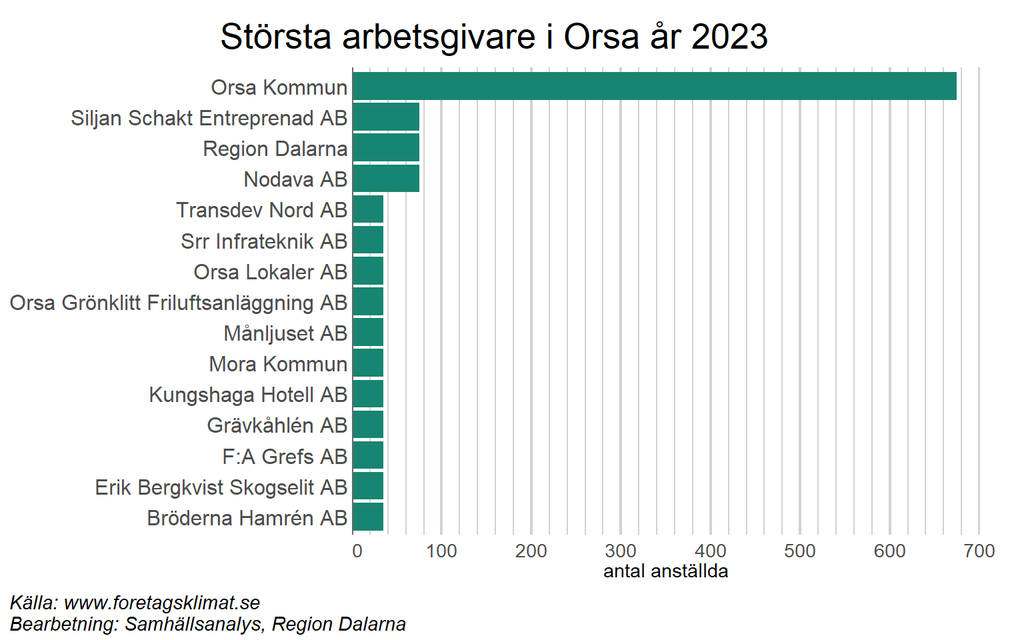

Orsa är som sagt en av Dalarnas minsta kommuner sett till folkmängd och har följaktligen en relativt låg branschbredd. Samtidigt är antalet företag som krävs för att den aggregerade lönesumman skall uppgå till 50 procent av den totala lönesumman (inom det privata näringslivet) högre än ett par befolkningsmässigt större kommuner i Dalarna. Positivt är också att det startas många nya företag per 1000 invånare. Samtidigt gick dock relativt många företag i konkurs 2024 (högst antal i dalarna per 1000 invånare). Det bör dock noteras att Orsa är en liten kommun och att små förändringar i antalet företag kan ge stora utslag i statistiken mellan år.

Sammanfattningsvis kan Orsa sägas vara en kommun som uppvisar låg sårbarhet på ett par områden. Arbetslösheten är under genomsnittet i Dalarna och en stor utpendling minskar arbetsmarknadens sårbarhet. Dessutom startas relativ många företag per 1000 invånare. Inom det privata näringslivet är byggindustrin den klart största sektorn, vilket dock potentiellt kan vara en sårbarhet.

## Rättvik

Rättviks kommun hade en folkmängd på 10 994 personer i november 2025. Befolkningen minskade fram till 1990-talet men var därefter relativt konstant och ökade till och med något under åren mot slutet av 2010-talet. Detta kan, precis som i de flesta kommuner i Dalarna, tillskrivas en ökad invandring, även om andelen utrikes födda är lägre i Rättvik än i många andra Dalakommuner. På senare år har dock befolkningen återigen börjat minska något. Rättvik är Sveriges nionde äldsta kommun, med en medelålder på närmare 50 år, vilket är klart högst i Dalarna. Arbetslösheten i Rättvik (3,5 procent) är lägre än genomsnittet i Dalarna, men det är även andelen högutbildade. Ungefär var tredje av de boende i Rättvik som arbetar gör det i en annan kommun, samtidigt som få (runt 20 procent) av de förvärvsarbetande i Rättvik bor i en annan kommun.

Rättvik har länge varit en populär turistort, vilket märks genom att dubbelt så stor andel jobbar inom hotell- och restaurangbranschen jämfört med genomsnittet i Dalarna. Även inom kultur, fritid och nöje, en bransch med tydliga kopplingar till turism, arbetar en klart större andel av de förvärvsarbetande i Rättvik jämfört med Dalarna som helhet.

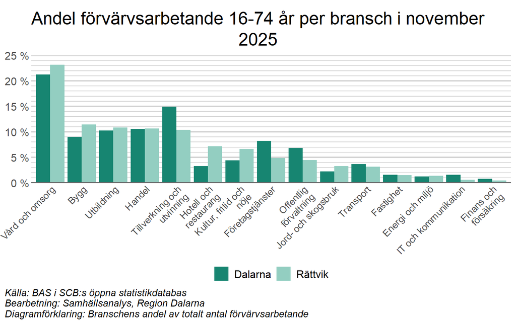

Baserat på branschgruppens andel av lönesumman inom det privata näringslivet i Rättvik är byggindustri störst, med ca 21 procent av den totala lönesumman. Få utrikes födda, få högutbildade och få kvinnor finns bland de sysselsatta inom branschgruppen. Även parti- och detaljhandel samt hotell och restaurang är viktiga branschgrupper, med tillsammans över 20 procent av den totala lönesumman. Den sistnämnda branschgruppen har en övervikt av kvinnor bland de sysselsatta, samt relativt många utrikes födda.

De fem största branscherna i Rättvik 2023 inom det privata näringslivet

| Bransch | Sysselsatta | Lönesumma (%)<sup>1</sup> | Kvinnor (%)<sup>2</sup> | Högutbildade (%)<sup>2,3</sup> | Utrikes födda (%)<sup>2</sup> |
| --- | --- | --- | --- | --- | --- |
| Byggindustri | 534 | 21 | 10 | 9 | 4 |
| Parti- o detaljhandel rep av hushållsartiklar | 531 | 14 | 54 | 17 | 7 |
| Hotell o restaurang | 577 | 9 | 58 | 13 | 17 |
| Företagsservicefirmor | 348 | 8 | 39 | 40 | 9 |
| Renhållning kultur sport m.m. | 334 | 6 | 53 | 27 | 6 |

Källa: SCB, bearbetning: Samhällsanalys, Region Dalarna, * -> för litet tal  
<sup>1</sup> Andel av total lönesumma inom det privata näringslivet  
<sup>2</sup> Andel inom bransch  
<sup>3</sup> Med högutbildade menas eftergymnasialt utbildade i denna tabell.

Den klart största arbetsgivaren i Rättvik var 2023 Rättviks Kommun med knappt 1 300 anställda. Bland övriga arbetsgivare är Rättvik Event störst med ungefär 300 anställda.

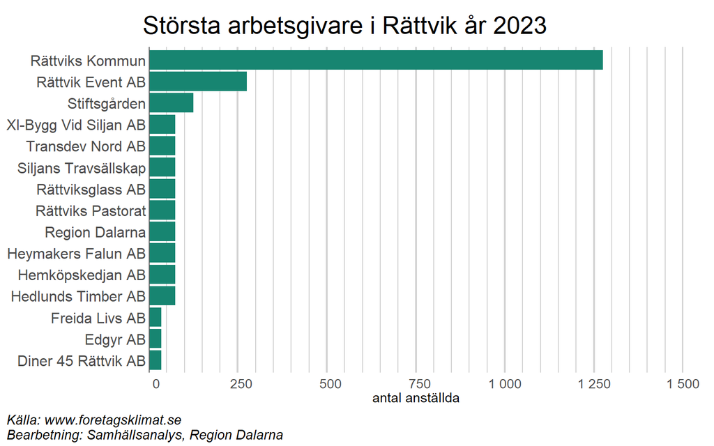

Rättvik tillhör Dalarnas bästa kommuner vad gäller antalet privata arbetsställen per 1000 invånare och har en hög andel företagssamma individer (näst bäst i Dalarna). Dessutom ökade antalet nystartade företag per 1000 invånare tydlligt mellan 2023 och 2024.

När det kommer till antalet företag som krävs för att den aggregerade lönesumman skall uppgå till 50 procent av den totala lönesumman är Rättvik tredje bäst i Dalarna. De enda kommunerna som har ett lägre beroende (Falun och Borlänge) har en betydligt större folkmängd. Rättvik har således ett väldigt litet beroende av enskilda företag.

Sammanfattningsvis kan Rättvik sägas vara en kommun som uppvisar låg sårbarhet på flera områden enligt vår modell, då arbetslösheten är relativt låg och förhållandevis många pendlar till andra kommuner. Dessutom har Rättvik ett lågt beroende av enskilda företag. Bland orosmolnen finns Dalarnas äldsta befolkning.

## Smedjebacken

Smedjebackens kommun hade 10 754 invånare i november 2025. Folkmängden minskade stadigt från åren runt finanskrisen (tidigt 1990-tal) fram till början av 2010-talet, men ökade därefter under några år. På senare tid har folkmängden återigen minskat något. Arbetslösheten i Smedjebacken, 3,9 procent, är något lägre än genomsnittet i Dalarna, vilket även gäller utbildningsnivån. Smedjebacken är Dalarnas fjärde äldsta kommun, med en medelålder på ungefär 48 år. Detta är exempelvis klart högre än närbelägna Ludvika. Smedjebacken är även en av Dalarnas största pendlarkommuner. Mer än hälften av de som bor i kommunen och förvärvsarbetar har sin arbetsplats i en annan kommun, Ludvika i stor utsträckning.

Som namnet antyder har Smedjebacken en lång historia kopplad till smedjor, men fungerade även länge som knutpunkt för land- och vattentransporter. Än idag är företag inom tillverkning och utvinning dominerande inom kommunen, ungefär var fjärde förvärvsarbetande arbetar inom sådana företag. Även arbetsgivare inom vård och omsorg är viktiga, med ca 22 procent av de förvärvsarbetande i kommunen.

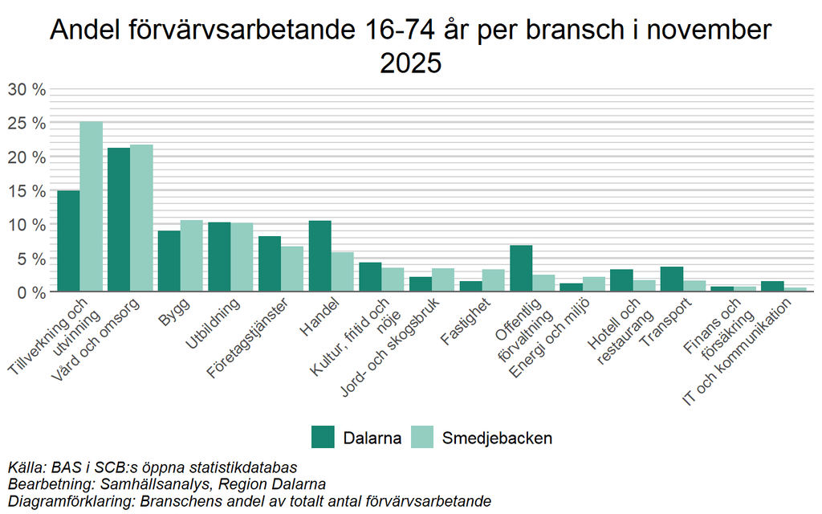

Den största privata arbetsgivaren i Smedjebacken finns inom branschgruppen stål- och metallverk . Branschens företag står för 24 procent av den totala lönesumman. Inom branschgruppen jobbar få utrikes födda och få kvinnor, och dessutom relativt få högutbildade. Även byggindustri och metallvaruindustri är viktiga branschgrupper sett till andel av lönesumman, och tillsammans med stål- och metallverk står dessa för ungefär halva lönesumman inom det privata näringslivet. Även företag inom branschgruppen företagsservicefirmor anställer relativt många men här återfinns en ganska stor andel kvinnor, högutbildade och utrikes födda.

De fem största branscherna i Smedjebacken 2023 inom det privata näringslivet

| Bransch | Sysselsatta | Lönesumma (%)<sup>1</sup> | Kvinnor (%)<sup>2</sup> | Högutbildade (%)<sup>2,3</sup> | Utrikes födda (%)<sup>2</sup> |
| --- | --- | --- | --- | --- | --- |
| Stål- o metallverk | 419 | 24 | 18 | 14 | 6 |
| Byggindustri | 317 | 13 | 12 | 9 | 6 |
| Företagsservicefirmor | 301 | 12 | 33 | 31 | 12 |
| Metallvaruindustri; ej maskinindustri | 260 | 11 | 12 | 13 | 13 |
| Övrig tillverkningsindustri | 143 | 7 | 7 | 6 | 8 |

Källa: SCB, bearbetning: Samhällsanalys, Region Dalarna, * -> för litet tal  
<sup>1</sup> Andel av total lönesumma inom det privata näringslivet  
<sup>2</sup> Andel inom bransch  
<sup>3</sup> Med högutbildade menas eftergymnasialt utbildade i denna tabell.

Den största arbetsgivaren i Smedjebacken var 2023 Smedjebackens Kommun med knappt 1 000 anställda. Bland privata arbetsgivare var Ovako störst, med närmare 400 anställda.

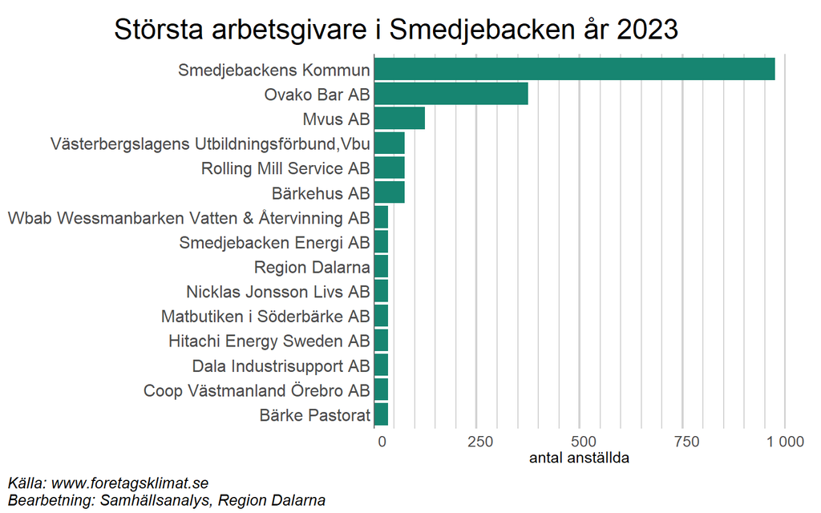

Smedjebacken har Dalarnas lägsta antal privata arbetsställen per 1 000 invånare och få nystartade företag, men samtidigt färre konkurser (per 1000 invånare) än länets genomsnitt. Konkurserna har dessutom minskat mellan 2023 och 2024.

Branschbredden i Smedjebacken är bland de lägsta i Dalarna och låg på ungefär samma nivå 2023 som 2015. Även antalet företag som utgör 50 procent av den aggregerade lönesumman är bland de lägsta i Dalarna (10), vilket indikerar att Smedjebacken är en kommun med relativt högt beroende. Visserligen är pendlingen hög, men denna pendling går i stor utsträckning till närbelägna Ludvika med en väldigt dominerande arbetsgivare.

Sammanfattningsvis kan Smedjebacken sägas vara en kommun som uppvisar sårbarhet på ett par områden. Visserligen är arbetslösheten bara runt genomsnittet för Dalarna och kommunen har en stor utpendling, men den pendlingen går i stor uträckning till närbelägna Ludvika som domineras av en enskild arbetsgivare. Beroendet av enskilda företag och branscher i Smedjebacken är dessutom högt och det finns relativt få arbetsställen. Naturligtvis finns samtidigt positiva sidor med att ha en stor och expanderande arbetsgivare (Hitachi) bara någon mil bort.

## Säter

Säters kommun hade 11 225 invånare i november 2025. Befolkningen ökade avsevärt från slutet av 1960-talet till början av 1990-talet, men minskade därefter. Från mitten av 2010-talet började folkmängden återigen att öka, vilket kan tillskrivas såväl en ökning bland inrikes som utrikes födda invånare. Arbetslösheten i Säter, 3 procent, är klart lägre än genomsnittet i Dalarna, samtidigt som andelen högutbildade är något lägre än genomsnittet i Dalarna. Att arbetslösheten är låg kan delvis tillskrivas den relativt låga andelen utrikes födda i Säter, en grupp där arbetslösheten vanligtvis är högre än bland inrikes födda. Exempelvis har närbelägna Borlänge mer än dubbelt så stor andel utrikes födda och dessutom klart högre arbetslöshet. Medelåldern i Säter är relativt låg, ca 46 år, men samtidigt klart högre än i närbelägna Borlänge. Säter är, tillsammans med Gagnef, den kommun som har störst pendling i Dalarna, mer än 50 procent av de som bor i Säter och förvärvsarbetar har sin arbetsplats på annan ort.

Säter fick stadsprivilegier redan på 1600-talet och är bland annat känt för Säters sjukhus, som under en period var Sveriges största mentalsjukshus. Idag arbetar en stor andel av de sysselsatta inom vård och omsorg, ungefär 33 procent av de förvärvsarbetande, vilket är den högsta andelen bland Dalarnas kommuner.

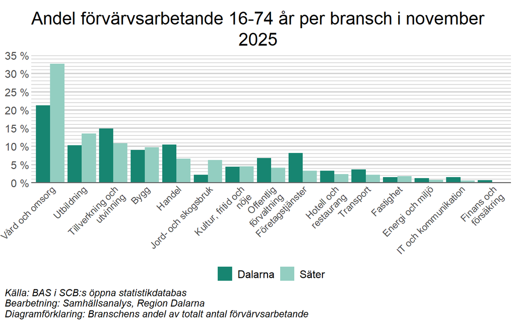

Baserat på andelen av lönesumman inom det privata näringslivet i Säter är byggindustri den största branschgruppen, med 19 procent av den totala lönesumman. Få utrikes födda, få högutbildade och få kvinnor är sysselsatta inom byggbranschen. Även parti- och detaljhandeln samt företagsservicefirmor är viktiga branschgrupper. I dessa båda finns en klart större andel kvinnor och högutbildade bland de sysselsatta.

De fem största branscherna i Säter 2023 inom det privata näringslivet

| Bransch | Sysselsatta | Lönesumma (%)<sup>1</sup> | Kvinnor (%)<sup>2</sup> | Högutbildade (%)<sup>2,3</sup> | Utrikes födda (%)<sup>2</sup> |
| --- | --- | --- | --- | --- | --- |
| Byggindustri | 390 | 19 | 9 | 6 | 7 |
| Parti- o detaljhandel rep av hushållsartiklar | 278 | 9 | 60 | 23 | 8 |
| Företagsservicefirmor | 214 | 8 | 32 | 38 | 9 |
| Jordbruk | 170 | 6 | 38 | 13 | 11 |
| Hälso- o sjukvård omsorg | 205 | 6 | 55 | 33 | 18 |

Källa: SCB, bearbetning: Samhällsanalys, Region Dalarna, * -> för litet tal  
<sup>1</sup> Andel av total lönesumma inom det privata näringslivet  
<sup>2</sup> Andel inom bransch  
<sup>3</sup> Med högutbildade menas eftergymnasialt utbildade i denna tabell.

Den största arbetsgivaren i Säter var år 2023 Säters Kommun med strax under 1 400 anställda. Även Region Dalarna är en stor arbetsgivare, medan det inom det privata näringslivet bara finns ett företag med mer än 50 anställda (Gustafs Scandinavia).

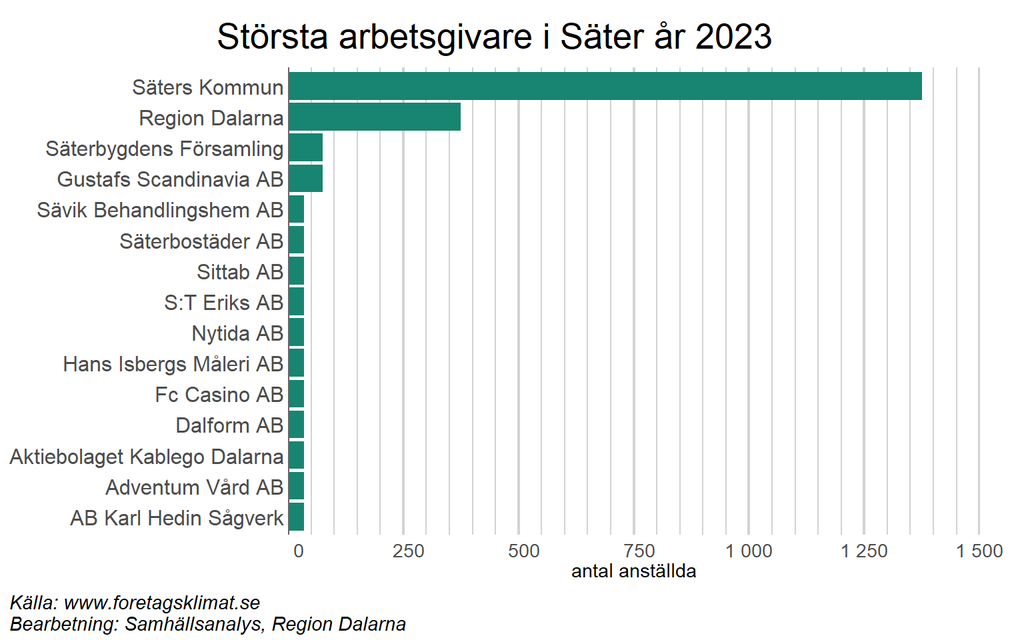

Antalet arbetsställen per 1 000 invånare i Säter är något under genomsnittet i Dalarna, vilket även gäller antalet nystartade företag (per 1 000 invånare). Antalet konkurser per 1000 invånare är dessutom bland de lägsta i Dalarna. Branschbredden i Säter är i linje med många andra kommuner av samma storlek, men antalet företag som krävs för att den aggregerade lönesumman skall uppgå till 50 procent av den totala lönesumman i det privata näringslivet (41) är avsevärt mycket större än många jämförbara kommuner. Säter kan därför sägas vara en kommun med relativt litet beroende. Samtidigt skall man vara medveten om att andelen som arbetar inom vård och omsorg i Säter (där många arbetsgivare tillhör det offentliga) är högst i Dalarna, vilket är ett annat typ av beroende.

Sammanfattningsvis är Säter en kommun med låg sårbarhet inom flera områden. Arbetslösheten är bland de lägre i Dalarna och det sker en stor pendling till framförallt närbelägna Borlänge. Dessutom är beroendet av enskilda företag och branscher, inom den privata sektorn, lågt. På minussidan finns en stor dominans av arbetsgivare inom vård och omsorg, vilket potentiellt kan vara en sårbarhet. Det är dock rimligt att tänka sig att företag inom offentliga verksamheter påverkas annorlunda än det privata näringslivet vid exempelvis en nedgång i konjunkturen, samtidigt som behovet av tjänster kopplade till vård och omsorg sannolikt kommer att öka i framtiden. Noterbart är även att bygg är en klart dominerande bransch inom det privata näringslivet, vilket potentiellt skulle kunna bli ett problem.

## Vansbro

Vansbro är, med sina 6 737 invånare i november 2025, Dalarnas minsta kommun. Folkmängden minskade stadigt fram till mitten av 2010-talet, innan den ökade tydligt under framförallt 2016. Därefter har folkmängden minskat under en majoritet av åren. Vansbro har en av Dalarnas lägsta arbetslösheter, 3 procent, men samtidigt är det också den kommun som har lägst andel högutbildade. Att arbetslösheten är låg i Vansbro kan delvis tillskrivas den relativt låga andelen utrikes födda (drygt 10 procent), vilket är klart lägre än i många andra Dalakommuner. Pendlingen till och från kommunen tillhör länets lägsta, vilket kan ha att göra med kommunens geografiska läge i västra Dalarna.

Idag är Vansbro i första hand förknippat med ett antal större företag, såsom Lyko och Orkla, som står för en stor andel av de sysselsatta i kommunen. Detta återspeglas i figuren nedan, som visar att mer än 40 procent av Vansbros förvärvsarbetande arbetar inom tillverknings- och utvinningsbranschen samt handel.

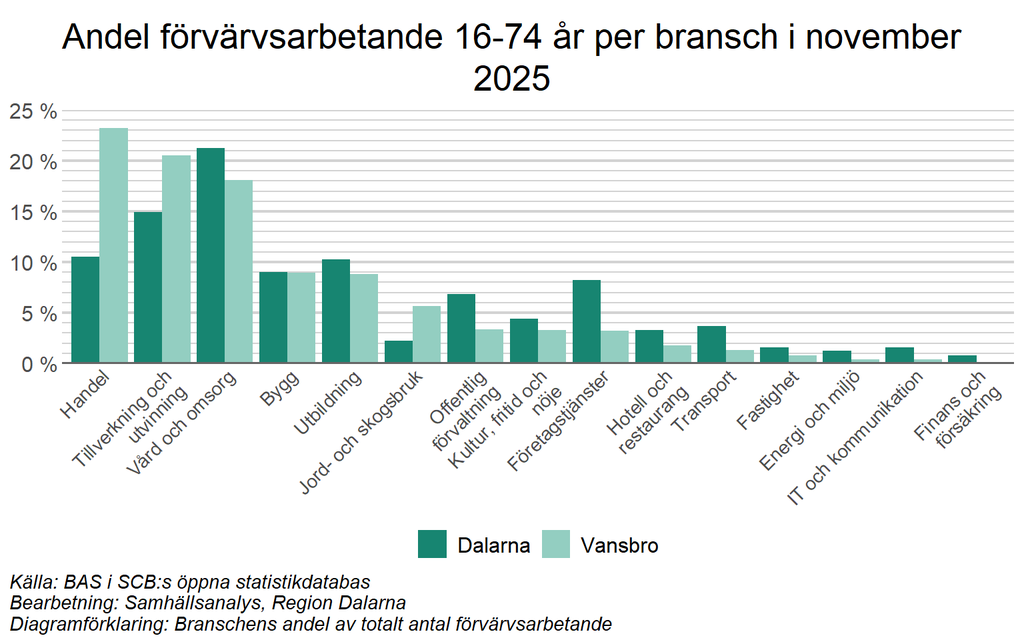

De största privata arbetsgivarna i Vansbro finns inom branschgruppen parti- och detaljhandel, vars företag står för drygt 23 procent av den totala lönesumman. Inom branschgruppen jobbar många kvinnor (>50 procent) och, i jämförelse med genomsnittet i Vansbro, många högutbildade. Bland övriga stora branschgrupper återfinns bland annat byggindustri och livsmedelsindustri, som tillsammans står för 23 procent av den totala lönesumman. I den sistnämnda branschen jobbar relativt många kvinnor.

De fem största branscherna i Vansbro 2023 inom det privata näringslivet

| Bransch | Sysselsatta | Lönesumma (%)<sup>1</sup> | Kvinnor (%)<sup>2</sup> | Högutbildade (%)<sup>2,3</sup> | Utrikes födda (%)<sup>2</sup> |
| --- | --- | --- | --- | --- | --- |
| Parti- o detaljhandel rep av hushållsartiklar | 615 | 23 | 54 | 19 | 16 |
| Byggindustri | 306 | 13 | 9 | 9 | 6 |
| Metallvaruindustri; ej maskinindustri | 232 | 11 | 14 | 8 | 18 |
| Livsmedels- och dryckes- och tobaksindustri | 217 | 10 | 51 | 13 | 18 |
| Sågverk träimpregneringsverk | 140 | 7 | 15 | 13 | * |

Källa: SCB, bearbetning: Samhällsanalys, Region Dalarna, * -> för litet tal  
<sup>1</sup> Andel av total lönesumma inom det privata näringslivet  
<sup>2</sup> Andel inom bransch  
<sup>3</sup> Med högutbildade menas eftergymnasialt utbildade i denna tabell.

Den största arbetsgivaren i Vansbro var år 2023 Vansbro Kommun med ungefär 1 000 anställda. Inom det privata arbetslivet jobbade flest, drygt 300 på Lyko.

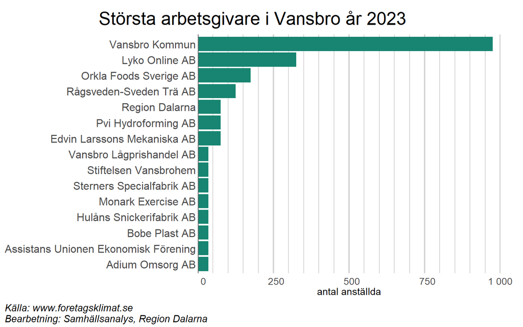

Antalet arbetsställen per 1 000 invånare är något högre i Vansbro än genomsnittet i Dalarna, vilket även gäller antalet nystartade företag. Samtidigt minskade även antalet konkurser per 1000 invånare tydligt år 2024 jämfört med året innan. Viktigt att notera är dock att Vansbro är en liten kommun, vilket gör att små förändringar i antalet konkurser från ett år till ett annat kan ge stora utslag i statistiken.

Vansbro är som sagt Dalarnas minsta kommun sett till befolkning och har följaktligen också en av de lägsta branschbredderna i länet. Även antalet företag som utgör 50 procent av den aggregerade lönesumman är bland de lägsta i Dalarna (12), vilket indikerar att Vansbro är en kommun med relativt högt beroende.

Sammanfattningsvis är Vansbro en kommun som uppvisar både sårbara och inte sårbara sidor. Arbetslösheten är låg, vilket indikerar en arbetsmarknad med god resiliens mot kriser. Samtidigt är Vansbro beroende av ett fåtal större företag inom ett par olika branscher, vilket är en riskfaktor. Dessutom är pendlingen relativt låg. Noterbart är dock att den största privata arbetsgivaren, Lyko, är ett familjeägt, och hittills expansivt, företag med en uttalad ambition att finnas i Vansbro.

## Älvdalen

Älvdalens kommun har länets näst lägsta folkmängd, med 6 834 invånare i november 2025. Befolkningen minskade stadigt fram till mitten av 2010-talet, innan det skedde en viss ökning under framförallt 2017 och 2018. På senare år har folkmängden återigen börjat minska. Arbetslösheten, ungefär 3,2 procent, är under genomsnittet i Dalarna, men samtidigt har Älvdalen näst lägst andel högutbildade. Att arbetslösheten är låg i Älvdalen kan delvis tillskrivas den relativt låga andelen utrikes födda (under 10 procent), vilket är klart lägre än i många andra Dalakommuner. Precis som för många andra kommuner i norra och västra Dalarna är pendlingen låg, drygt var femte boende i Älvdalen som förvärvsarbetar gör det i en annan kommun.

Älvdalen är Dalarnas till ytan största kommun, mer än dubbelt så stor som Falun och Borlänge tillsammans. Kommunen är idag kanske mest känd för en omfattande turismindustri, som domineras av diverse aktörer i området kring Idre och Grövelsjön (“Kultur, fritid och nöje.” och “Hotell och restaurang” i figuren nedan). Kopplad till den “boom” som skett inom turismindustrin på senare år, har även byggsektorn expanderat och står för ungefär 15 procent av de förvärvsarbetande. I jämförelse med Dalarna sticker även företag inom jord- och skogsbruk ut, där dubbelt så stor andel arbetar jämfört med snittet i länet.

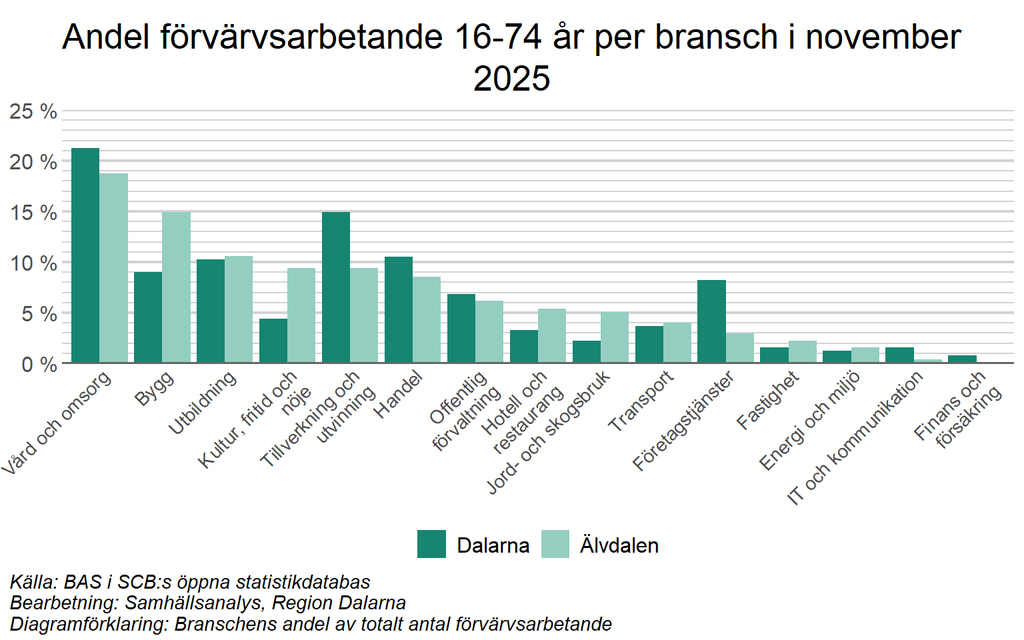

Baserat på branschgruppens andel av lönesumman inom det privata näringslivet i Älvdalen är byggindustri den största branschgruppen, med 22 procent av den totala lönesumman. Få utrikes födda, få högutbildade och få kvinnor är sysselsatta inom branschgruppen. Även företag inom renhållning, kultur, sport mm, som bland annat innefattar företag inom turism, har många anställda (448) och en relativt stor andel av lönesumman (ca 14 procent). Inom den branschgruppen är avsevärt många fler kvinnor anställda. Bland övriga stora branschgrupper kan parti- och detaljhandel nämnas, vars företag har 370 anställda och står för 11 procent av den totala lönesumman.

De fem största branscherna i Älvdalen 2023 inom det privata näringslivet

| Bransch | Sysselsatta | Lönesumma (%)<sup>1</sup> | Kvinnor (%)<sup>2</sup> | Högutbildade (%)<sup>2,3</sup> | Utrikes födda (%)<sup>2</sup> |
| --- | --- | --- | --- | --- | --- |
| Byggindustri | 484 | 22 | 8 | 9 | 8 |
| Renhållning kultur sport m.m. | 448 | 14 | 53 | 17 | 8 |
| Parti- o detaljhandel rep av hushållsartiklar | 372 | 11 | 57 | 16 | 7 |
| Hotell o restaurang | 276 | 7 | 56 | 24 | 25 |
| Metallvaruindustri; ej maskinindustri | 148 | 7 | 29 | 20 | 6 |

Källa: SCB, bearbetning: Samhällsanalys, Region Dalarna, * -> för litet tal  
<sup>1</sup> Andel av total lönesumma inom det privata näringslivet  
<sup>2</sup> Andel inom bransch  
<sup>3</sup> Med högutbildade menas eftergymnasialt utbildade i denna tabell.

Den största arbetsgivaren i Älvdalen var år 2023 Älvdalens Kommun med mer än 800 anställda. Inom det privata näringslivet hade Idre Fjäll flest anställda, med knappt 300.

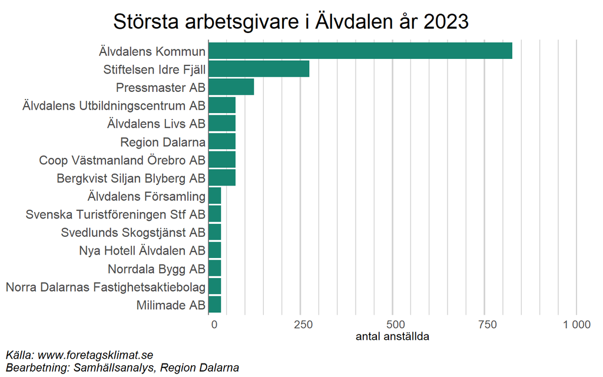

Befolkningsmässigt är Älvdalen en liten kommun och har följaktligen en låg branschbredd (ungefär en fjärdedel av branscherna finns representerade i kommunen). Dock är antalet företag som utgör 50 procent av den aggregerade lönesumman högre än i många jämförbara kommuner, vilket indikerar att Älvdalen inte är en kommun med överdrivet stort beroende. Älvdalen har dessutom näst flest privata arbetsställen per 1 000 invånare i Dalarna och en relativt stor andel individer anses vara företagssamma.

Sammanfattningsvis är Älvdalen en kommun som uppvisar låg sårbarhet på flera områden. Arbetslösheten är relativt låg samtidigt som beroendet av enskilda företag eller branscher inte är överdrivet stort, även om det finns ett visst beroende av företag inom byggindustri. Kommunen har dessutom näst flest privata arbetsställen per 1 000 invånare i Dalarna. Precis som är fallet med Malung-Sälens kommun är turism kopplad till fjällvärlden en viktig näring i Älvdalen, vilket dock kan vara en osäkerhet kopplad till klimatförändringar och dess effekter på snötillgång, men även till konjunkturen då exempelvis skidturism är en relativt dyr fritidsaktivitet. Viktigt att poängtera är också att den modell för att utvärdera sårbarhet som används i denna analys inte tar hänsyn till kopplingar mellan branscher, exempelvis hur många olika branscher som är kopplade till ekonomin runt turismen i Älvdalen.